# Learning ML with Titanic Survival

# Modelling:

Now let us focus on the modelling part.I intent to use the random forest model .Let us first visualize whether relevant missing values are imputed correctly.

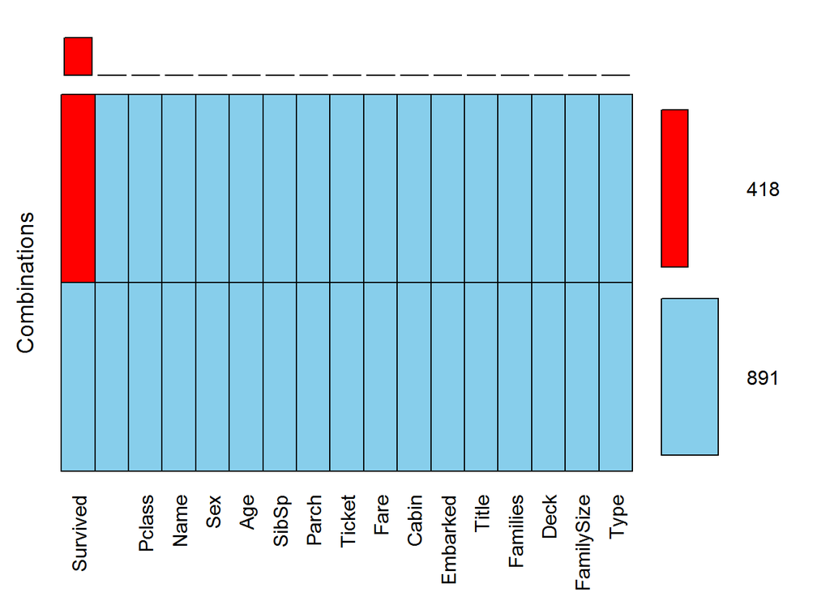

```
##
##  Variables sorted by number of missings:
##     Variable Count
##     Survived   418
##  PassengerId     0
##       Pclass     0
##         Name     0
##          Sex     0
##          Age     0
##        SibSp     0
##        Parch     0
##       Ticket     0
##         Fare     0
##        Cabin     0
##     Embarked     0
##        Title     0
##     Families     0
##         Deck     0
##   FamilySize     0
##         Type     0
```

```r
aggr(titanic,prop=FALSE,combined=TRUE,sortVars=TRUE,sortCombs=TRUE,numbers=TRUE)
```

Thus from the data we understand that there are no missing value in training data.The test data has 418 missing values on Survived which needs to be predicted.Let us split the train and test dataset.

We convert the character variables into factors.

```r
titanic = titanic %>% mutate(Type=factor(Type)) %>% mutate(Embarked=factor(Embarked)) %>% mutate(Sex=factor(Sex))
```

```r
train=titanic[1:891,]
test=titanic[892:1309,]
names(train)
```

```
##  [1] "PassengerId" "Survived"    "Pclass"      "Name"        "Sex"
##  [6] "Age"         "SibSp"       "Parch"       "Ticket"      "Fare"
## [11] "Cabin"       "Embarked"    "Title"       "Families"    "Deck"
## [16] "FamilySize"  "Type"
```

```r
str(train)
```

```
## 'data.frame':    891 obs. of  17 variables:
##  $ PassengerId: int  1 2 3 4 5 6 7 8 9 10 ...
##  $ Survived   : Factor w/ 2 levels "No","Yes": 1 2 2 2 1 1 1 1 2 2 ...
##  $ Pclass     : int  3 1 3 1 3 3 1 3 3 2 ...
##  $ Name       : chr  "Braund, Mr. Owen Harris" "Cumings, Mrs. John Bradley (Florence Briggs Thayer)" "Heikkinen, Miss. Laina" "Futrelle, Mrs. Jacques Heath (Lily May Peel)" ...
##  $ Sex        : Factor w/ 2 levels "female","male": 2 1 1 1 2 2 2 2 1 1 ...
##  $ Age        : num  22 38 26 35 35 ...
##  $ SibSp      : int  1 1 0 1 0 0 0 3 0 1 ...
##  $ Parch      : int  0 0 0 0 0 0 0 1 2 0 ...
##  $ Ticket     : chr  "A/5 21171" "PC 17599" "STON/O2. 3101282" "113803" ...
##  $ Fare       : num  7.25 71.28 7.92 53.1 8.05 ...
##  $ Cabin      : chr  "" "C85" "" "C123" ...
##  $ Embarked   : Factor w/ 3 levels "C","Q","S": 3 1 3 3 3 2 3 3 3 1 ...
##  $ Title      : Factor w/ 6 levels "Ranked","Royalty",..: 6 5 4 5 6 6 6 3 5 5 ...
##  $ Families   : Factor w/ 2 levels "No","Yes": 2 2 1 2 1 1 1 2 2 2 ...
##  $ Deck       : Factor w/ 8 levels "A","B","C","D",..: 7 3 3 3 3 3 5 6 1 3 ...
##   ..- attr(*, "imputed")= int  1 3 5 6 8 9 10 13 14 15 ...
##  $ FamilySize : num  2 2 1 2 1 1 1 5 3 2 ...
##  $ Type       : Factor w/ 3 levels "2 People","Large",..: 1 1 3 1 3 3 3 2 2 1 ...
```

```r
rfmodel=randomForest(factor(Survived) ~ Pclass+Sex+Age+Fare+Embarked+Title+Deck+FamilySize+Type+SibSp+Parch,data=train,importance=TRUE)
print(rfmodel)
```

```
##
## Call:
##  randomForest(formula = factor(Survived) ~ Pclass + Sex + Age +      Fare + Embarked + Title + Deck + FamilySize + Type + SibSp +      Parch, data = train, importance = TRUE)
##                Type of random forest: classification
##                      Number of trees: 500
## No. of variables tried at each split: 3
##
##         OOB estimate of  error rate: 17.4%
## Confusion matrix:
##      No Yes class.error
## No  496  53  0.09653916
## Yes 102 240  0.29824561
```

The confusion matrix shows that the classification error is 30 %.

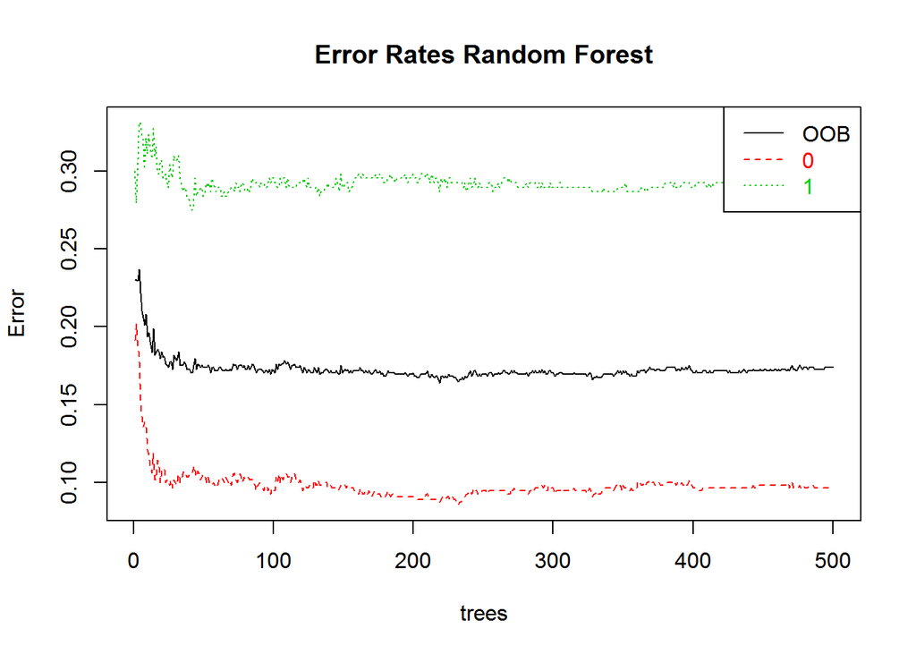

```r
plot(rfmodel, main="")
legend("topright", c("OOB", "0", "1"), text.col=1:6, lty=1:3, col=1:3)
title(main="Error Rates Random Forest")
```

The plot shows that somewhere between 0-100 trees,the optimum is reached and after that the OOB error becomes flat.Let us check the variable importance.

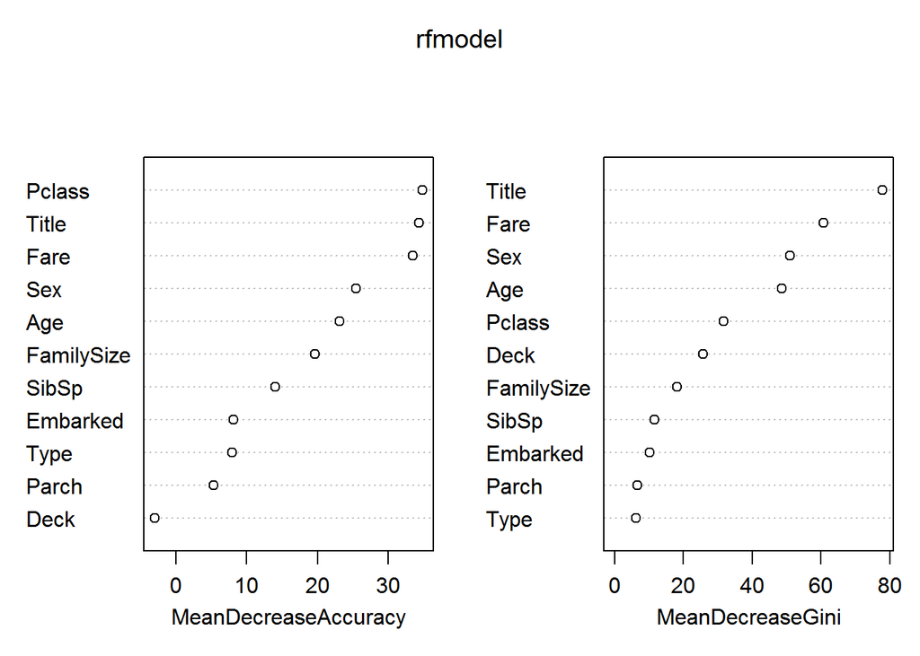

```r
varImpPlot(rfmodel)
```

Let us tune our randomforest.

```r
variable=c("Pclass","Sex","Age","Fare","Embarked","Title","Deck","FamilySize","Type","SibSp","Parch")
tunedrfmodel=tuneRF(x=train[,variable],y=as.factor(train$Survived),mtryStart = 3,ntreeTry = 100,stepFactor = 2,improve=0.001,trace=FALSE,plot=FALSE,doBest = TRUE,nodesize=200,importance=TRUE)
```

```
## -0.04597701 0.001
## 0.05172414 0.001
## -0.1818182 0.001
```

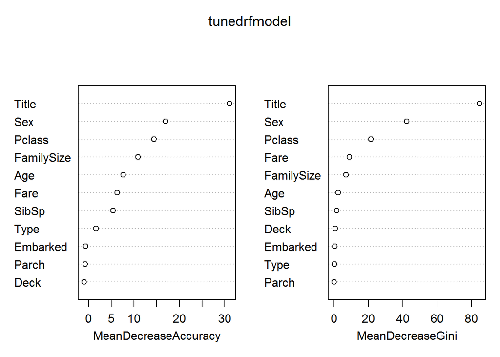

```r
varImpPlot(tunedrfmodel)
```

From the tuning,we see that title,sex are most important variable for our prediction.

Let us predict using the train data.

```r
trainpredict=table(predict(tunedrfmodel),train$Survived)
caret::confusionMatrix(trainpredict)
```

```
## Confusion Matrix and Statistics
##
##
##        No Yes
##   No  486  92
##   Yes  63 250
##
##                Accuracy : 0.826
##                  95% CI : (0.7995, 0.8504)
##     No Information Rate : 0.6162
##     P-Value [Acc > NIR] : < 2e-16
##
##                   Kappa : 0.6263
##  Mcnemar's Test P-Value : 0.02451
##
##             Sensitivity : 0.8852
##             Specificity : 0.7310
##          Pos Pred Value : 0.8408
##          Neg Pred Value : 0.7987
##              Prevalence : 0.6162
##          Detection Rate : 0.5455
##    Detection Prevalence : 0.6487
##       Balanced Accuracy : 0.8081
##
##        'Positive' Class : No
##
```

```r
test$Survived=NULL
titanicpred=predict(tunedrfmodel,test,OOB=TRUE,type="response")
titanicpred=ifelse(titanicpred=="No",0,1)
solution=data.frame(PassengerID=test$PassengerId,Survived=titanicpred)
write.csv(solution,file="submission.csv",row.names=F)
```

## Logistic Regression:

```r
library(lmtest)
logit=glm(factor(Survived) ~ Pclass+Sex+Age+Fare+Embarked+Title+Deck+FamilySize+Type+SibSp+Parch,data=train,family=binomial)
lrtest(logit)
```

```
## Likelihood ratio test
##
## Model 1: factor(Survived) ~ Pclass + Sex + Age + Fare + Embarked + Title +
##     Deck + FamilySize + Type + SibSp + Parch
## Model 2: factor(Survived) ~ 1
##   #Df  LogLik  Df  Chisq Pr(>Chisq)
## 1  23 -356.03
## 2   1 -593.33 -22 474.59  < 2.2e-16 ***
## ---
## Signif. codes:  0 '***' 0.001 '**' 0.01 '*' 0.05 '.' 0.1 ' ' 1
```

```r
#summary(logit)
pR2(logit)
```

```
##          llh      llhNull           G2     McFadden         r2ML
## -356.0312578 -593.3275684  474.5926212    0.3999415    0.4129537
##         r2CU
##    0.5610749
```

- The P value is highly significant which means that the likelihood of survival depends on the factors encoded in the formula.This implies that the null hypothesis is rejected.
- Macfaddem R2 value is 0.39 which means that 39 % of uncertainity of the intercept only model is explained by the full model.

```r
predlogit=predict(logit,type="response")
gg1=floor(predlogit+0.50)
table(Actual=train$Survived,Prediction=gg1)
```

```
##       Prediction
## Actual   0   1
##    No  489  60
##    Yes  90 252
```

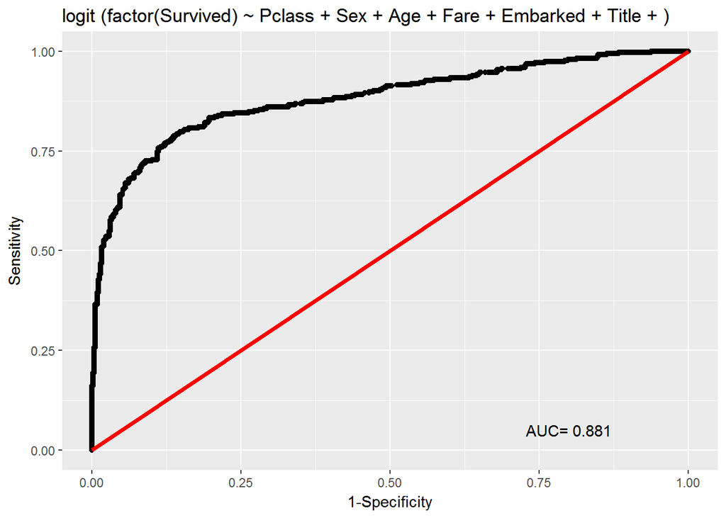

```r
rocplot(logit)
```

Using test data,

```r
logittest=predict(logit,type="response",newdata=test)
logittest=floor(logittest>0.5)
titanicpred=ifelse(logittest=="No",0,1)
solution=data.frame(PassengerID=test$PassengerId,Survived=titanicpred)
write.csv(solution,file="submission1.csv",row.names=F)
```

# Conclusion:

- This well known dataset in the kaggle community gives us the leverage to see the data in different angle gaining vast knowledge on how to visualise the data,impute missing values,various packages to model the data,accuraccy of the model etc.
- Overall,this dataset is an exposure to machine learning algorithms and interpretation of the same.